# Bay Area Bike Share Analysis

## Introduction

[Bay Area Bike Share](http://www.bayareabikeshare.com/) is a company that rents bicycles on-demand for customers in San Francisco, Redwood City, Palo Alto, Mountain View and San Jose. The customers can unlock the bicycles at several stations in one city and give them back at the same city. The customers can buy a subscription that allows them to use the system for a year or they can just buy single tickets for 24 hours or 3 days. They can travel as much as they want. Trips below 30 minutes do not have any additional cost while longer trips need extra payment.

## Data Wrangling

The [open data](http://www.bayareabikeshare.com/open-data) comes in three parts: first half of year 1 (from `8/29/13` to `2/28/14`), the second half of year 1 (from `3/1/14` to `8/31/14`) and all year 2 (from `9/1/14` to `8/31/15`). There are two data files for each part: trip data showing information about each single trip(`*_trip_data.csv`) and information about the stations (`*_station_data.csv`).

```python
# Imports all the required libraries
%matplotlib inline
import csv
from datetime import datetime
import numpy as np
import pandas as pd
from babs_datacheck import question_3
from babs_visualizations import usage_stats, usage_plot
from IPython.display import display
```

```python
# Files definition
file_in  = '201402_trip_data.csv'
file_out = '201309_trip_data.csv'

with open(file_out, 'w') as f_out, open(file_in, 'r') as f_in:
    # configure csv reader
    in_reader = csv.reader(f_in)
    out_writer = csv.writer(f_out)

    # write the data on the output file until the data limit is reached
    while True:
        datarow = next(in_reader)
        # start date has the format 'm/d/yyyy HH:MM'
        if datarow[2][:9] == '10/1/2013':
            break
        out_writer.writerow(datarow)
```

### Merging Trip Data

First I am going to check how data is structured in both files with the information about the half first year.

#### Trip Data

```python
# Read the file and print the header and first records of the file
trip_data = pd.read_csv('201402_trip_data.csv')
trip_data.head()
```

|  | Trip ID | Duration | Start Date | Start Station | Start Terminal | End Date | End Station | End Terminal | Bike # | Subscription Type | Zip Code |
| --- | --- | --- | --- | --- | --- | --- | --- | --- | --- | --- | --- |
| 0 | 4576 | 63 | 8/29/2013 14:13 | South Van Ness at Market | 66 | 8/29/2013 14:14 | South Van Ness at Market | 66 | 520 | Subscriber | 94127 |
| 1 | 4607 | 70 | 8/29/2013 14:42 | San Jose City Hall | 10 | 8/29/2013 14:43 | San Jose City Hall | 10 | 661 | Subscriber | 95138 |
| 2 | 4130 | 71 | 8/29/2013 10:16 | Mountain View City Hall | 27 | 8/29/2013 10:17 | Mountain View City Hall | 27 | 48 | Subscriber | 97214 |
| 3 | 4251 | 77 | 8/29/2013 11:29 | San Jose City Hall | 10 | 8/29/2013 11:30 | San Jose City Hall | 10 | 26 | Subscriber | 95060 |
| 4 | 4299 | 83 | 8/29/2013 12:02 | South Van Ness at Market | 66 | 8/29/2013 12:04 | Market at 10th | 67 | 319 | Subscriber | 94103 |

#### Station Data

```python
# Read the file and print the header and first records of the file
station_data = pd.read_csv('201402_station_data.csv')
station_data.head()
```

|  | station_id | name | lat | long | dockcount | landmark | installation |
| --- | --- | --- | --- | --- | --- | --- | --- |
| 0 | 2 | San Jose Diridon Caltrain Station | 37.329732 | -121.901782 | 27 | San Jose | 8/6/2013 |
| 1 | 3 | San Jose Civic Center | 37.330698 | -121.888979 | 15 | San Jose | 8/5/2013 |
| 2 | 4 | Santa Clara at Almaden | 37.333988 | -121.894902 | 11 | San Jose | 8/6/2013 |
| 3 | 5 | Adobe on Almaden | 37.331415 | -121.893200 | 19 | San Jose | 8/5/2013 |
| 4 | 6 | San Pedro Square | 37.336721 | -121.894074 | 15 | San Jose | 8/7/2013 |

After some analysis on both headers, some assesments on the data are important to be done.

Notice that on data trip, there is a column for the name of the start station, end station and also columns for the id of those stations. I want to keep just the id. Furthermore, I am going to focus this analysis with information from the columns: trip duration, Start date, start terminal and end terminal(just the ids) and finally one column for the type of subscription.

Start date will be transformed in four separeted columns: start_date (day), star_year, start_month and start_hour. Since there is a column for the duration of the trip, there is no need for End Date information. One column for day of the week will be added and start terminal and end terminal will contain information about the city they belong.

#### Assesments

- Create a mapping that gets the name of the city based on the station_id information

```python
def create_station_mapping(station_data):
    """
    TODO: add doc
    """
    station_map = {}
    # Read all the files in station_data list
    for data_file in station_data:
        with open(data_file, 'r') as f_in:
            # configure the object csv reader
            weather_reader = csv.DictReader(f_in)
            for row in weather_reader:
                station_map[row['station_id']] = row['landmark']
    return station_map
```

- Transform Start date in four columns: start_day, start_year, start_month and start_hour
- Calculate the duration in minutes instead of seconds
- Add a column day_of_the_week
- Display the name of the city in the columns start terminal and end terminal

The following funtion deals gets a list of files of trips, a list of files of stations, deal with the assesments described and write the result in a single file.

```python
def summarise_data(trip_in, station_data, trip_out):
    """
    TODO: add doc
    """
    # creates the mapping station_id and city
    station_map = create_station_mapping(station_data)

    with open(trip_out, 'w') as f_out:

        out_colnames = ['duration', 'start_day', 'start_year',
                        'start_month', 'start_hour', 'weekday',
                        'start_city', 'end_city', 'subscription_type']
        trip_writer = csv.DictWriter(f_out, fieldnames = out_colnames)
        trip_writer.writeheader()

        for data_file in trip_in:
            with open(data_file, 'r') as f_in:
                # configure the csv reader
                trip_reader = csv.DictReader(f_in)

                # read each line from the file
                for row in trip_reader:
                    new_point = {}

                    # Convert duration from seconds to minutes.
                    new_point['duration'] = int(row['Duration'])/60

                    # Strips start date into four different columns
                    trip_date = datetime.strptime(row['Start Date'], '%m/%d/%Y %H:%M')

                    new_point['start_day']  = trip_date.day
                    new_point['start_year']  = trip_date.year
                    new_point['start_month'] = trip_date.month
                    new_point['start_hour']  = trip_date.hour
                    new_point['weekday']     = trip_date.weekday()

                    # Maps Start Terminal and End Terminal into city
                    new_point['start_city'] = station_map[row['Start Terminal']]
                    new_point['end_city']   = station_map[row['End Terminal']]

                    # Cleaning the column Subscription Type
                    if 'Subscription Type' in row:
                        new_point['subscription_type'] = row['Subscription Type']

                    else:
                        new_point['subscription_type'] = row['Subscriber Type']

                    # Writes in the output file
                    trip_writer.writerow(new_point)
```

The following code gets the three files containing station and trip data and summarise it in one file:

```python
station_data = ['201408_station_data.csv',
                '201402_station_data.csv',
                '201508_station_data.csv']

trip_in = ['201402_trip_data.csv',
           '201408_trip_data.csv',
           '201508_trip_data.csv' ]
trip_out = 'babs_y1_y2_summary.csv'

summarise_data(trip_in, station_data, trip_out)
```

```python
# Display the header of the new file
trip_data = pd.read_csv('babs_y1_y2_summary.csv')
trip_data.head()
```

|  | duration | start_day | start_year | start_month | start_hour | weekday | start_city | end_city | subscription_type |
| --- | --- | --- | --- | --- | --- | --- | --- | --- | --- |
| 0 | 1.050000 | 29 | 2013 | 8 | 14 | 3 | San Francisco | San Francisco | Subscriber |
| 1 | 1.166667 | 29 | 2013 | 8 | 14 | 3 | San Jose | San Jose | Subscriber |
| 2 | 1.183333 | 29 | 2013 | 8 | 10 | 3 | Mountain View | Mountain View | Subscriber |
| 3 | 1.283333 | 29 | 2013 | 8 | 11 | 3 | San Jose | San Jose | Subscriber |
| 4 | 1.383333 | 29 | 2013 | 8 | 12 | 3 | San Francisco | San Francisco | Subscriber |

## Exploratory Analysis

The code bellow shows basic insights from the data:

```python
print('There are {:d} records on the data set'.format(trip_data.shape[0]))
print('The mean trip duration was {:.2f} minutes'.format(trip_data['duration'].mean()))
print('The median trip duration was {:.2f} minutes'.format(trip_data['duration'].median()))

# quartiles
duration_qtiles = trip_data['duration'].quantile([.25, .5, .75]).as_matrix()
print('25% of the trips were shorter than {:.2f} minutes'.format(duration_qtiles[0]))
print('25% of the trips were longer than {:.2f} minutes'.format(duration_qtiles[2]))
```

```
There are 669959 records on the data set
The mean trip duration was 18.47 minutes
The median trip duration was 8.62 minutes
25% of the trips were shorter than 5.73 minutes
25% of the trips were longer than 12.58 minutes
```

### Who uses the Bike share system?

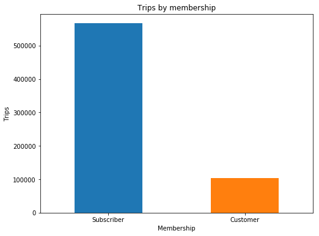

```python
import matplotlib.pyplot as plt

trip_data['subscription_type'].value_counts().plot(kind ='bar', figsize=(8,6), rot=0, title='Trips by membership');

plt.xlabel('Membership')
plt.ylabel('Trips')
plt.show()
```

### How long do the trips take?

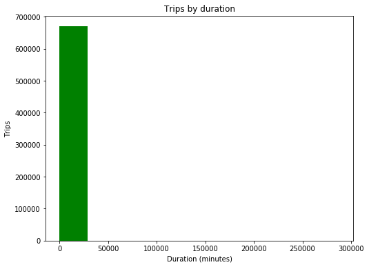

```python
trip_data['duration'].plot(kind='hist',figsize = (8,6), title='Trips by duration', color='green');


plt.xlabel('Duration (minutes)')
plt.ylabel('Trips')
plt.show()
```

It seems that there are a few trips that are very long. Since there is extra payment for trips longer than 30 minutes, it is important to focus where most part of the data is represented, since on this study the outliers were not removed from the data set.

```python
print('There are {:d} trips.'.format(trip_data.shape[0]))
trip_data_60 = trip_data.query('duration < 60')
print('There are {:d} trips shorter than 60 minutes.'.format(trip_data_60.shape[0]))
perc_shorter_60 = (trip_data_60.shape[0]/trip_data.shape[0])*100
print('Trips shorter than 60 minutes represents {:.2f} % of the data set.'.format(perc_shorter_60))
```

```
There are 669959 trips.
There are 648712 trips shorter than 60 minutes.
Trips shorter than 60 minutes represents 96.83 % of the data set.
```

Let's focus on those.

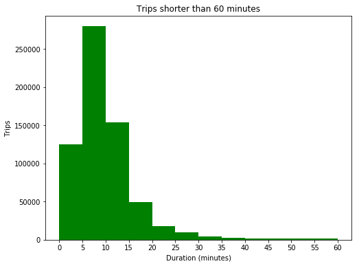

```python
# Trips less than 60 minutes
labels = [0,5,10,15,20,25,30,35,40,45,50,55,60]
trip_data_60['duration'].plot(kind='hist',xticks=labels, figsize = (8,6),range=(0,60), bins=labels, color='green');


plt.title('Trips shorter than 60 minutes')
plt.xlabel('Duration (minutes)')
plt.ylabel('Trips')
plt.show()
```

### Where is the system being used?

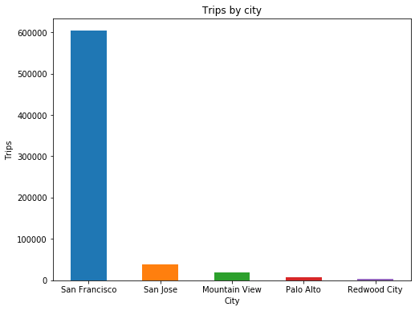

```python
trip_data['start_city'].value_counts().plot(kind='bar',figsize = (8,6), rot = 0);

plt.title('Trips by city')
plt.xlabel('City')
plt.ylabel('Trips')
plt.show()
```

### Are there differences between weekday and weekend?

```python
# Trip mean by weekday
trip_data.groupby(['weekday']).mean()['duration']
```

```
weekday
0    14.216484
1    13.534880
2    13.896800
3    14.571864
4    17.571230
5    46.906951
6    42.749314
Name: duration, dtype: float64
```

It is clear that there is a difference between work days and weekends. Let's check that together with type of subscription:

```python
trip_data_60.groupby(['subscription_type','weekday'])['duration'].mean()
```

```
subscription_type  weekday
Customer           0          17.616969
                   1          16.939221
                   2          16.618123
                   3          17.161492
                   4          17.889721
                   5          19.895920
                   6          19.961172
Subscriber         0           8.626501
                   1           8.605314
                   2           8.667668
                   3           8.708050
                   4           8.748561
                   5           9.514303
                   6           9.653977
Name: duration, dtype: float64
```

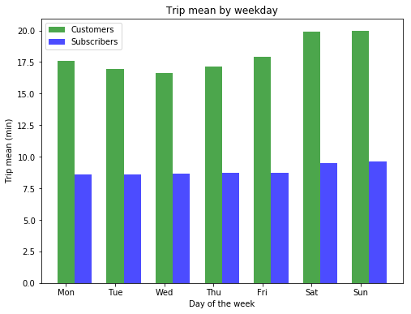

```python
# Mean trip duration by Subscription Type and Weekday
data_to_plot = trip_data_60.groupby(['subscription_type','weekday'])['duration'].mean()
customers = data_to_plot['Customer']
subscribers = data_to_plot['Subscriber']

ind = np.arange(7)  # Location on axix x
width = 0.35       # Bar width
labels = ['Mon','Tue','Wed','Thu','Fri','Sat','Sun',]

#barras
plt.figure(figsize=(8,6))
customers_bars = plt.bar(ind, customers, width, color='g', alpha=.7, label='Customers', tick_label=labels)
subscribers_bars = plt.bar(ind + width, subscribers, width, color='b', alpha=.7, label='Subscribers')

# title and labels
plt.ylabel('Trip mean (min)')
plt.xlabel('Day of the week')
plt.title('Trip mean by weekday')

# legend
plt.legend(loc=2)
plt.show()
```

Considering only trips shorter than 60 minutes to avoid the outliers. The trip mean for subscribers remains the same during work days, suggesting that they use the bicycles to commute, while among customers the trips are longer which may be the case that they are tourists or people that are not pressured by time the same way as commuters are. On the weekends, both means increases a little bit. Maybe people are more relaxed with time and cycle slower, or take different routes.

### What time of the day is most common to use the system?

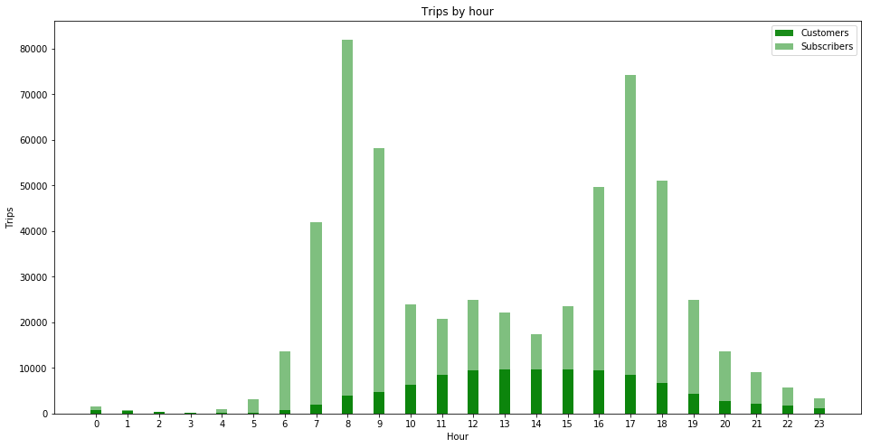

```python
# 24 hours
ind = np.arange(24)

start_hours = trip_data.groupby(['subscription_type','start_hour'])['subscription_type'].value_counts()

plt.figure(figsize=(16,8))
plt.bar(ind, start_hours['Customer'], width, color='green', alpha=.9, label='Customers', tick_label=ind)
plt.bar(ind, start_hours['Subscriber'], width, color='green', alpha=.5, label='Subscribers')

# Title and labels
plt.ylabel('Trips')
plt.xlabel('Hour')
plt.title('Trips by hour')

# legend
plt.legend(loc=1)
plt.show()
```

Notice how subscribers use the system from 07:00 to 10:00 and also from 16:00 to 19:00. It strongly suggests that they are in fact commuters. While among customers the distribuition increases until 13:00 and then starts to decrease.

### Brief outliers analysis (to be continued)

```python
# Trips longer than one day
minutes_day = 60*24
trip_data_outliers = trip_data.query('duration > @minutes_day')
```

```python
trip_data_outliers.info()
```

```
<class 'pandas.core.frame.DataFrame'>
Int64Index: 296 entries, 747 to 662378
Data columns (total 9 columns):
duration             296 non-null float64
start_day            296 non-null int64
start_year           296 non-null int64
start_month          296 non-null int64
start_hour           296 non-null int64
weekday              296 non-null int64
start_city           296 non-null object
end_city             296 non-null object
subscription_type    296 non-null object
dtypes: float64(1), int64(5), object(3)
memory usage: 23.1+ KB
```

```python
trip_data_outliers['duration'].describe()
```

```
count       296.000000
mean       4567.019144
std       16881.587884
min        1442.550000
25%        1674.183333
50%        2755.808333
75%        4098.716667
max      287840.000000
Name: duration, dtype: float64
```

```python
trip_data.groupby(['start_hour']).size()
```

```
start_hour
0      2171
1      1189
2       692
3       342
4      1022
5      3449
6     14312
7     43939
8     85864
9     62897
10    30106
11    29141
12    34384
13    31740
14    27156
15    33223
16    59099
17    82705
18    57652
19    29188
20    16527
21    11277
22     7434
23     4450
dtype: int64
```

There are *296* trips longer than 24 hours and the mean of this set is 4567 minutes, or *3,17 days*. Some hyphotesis may include: stolen bicycles, acidents, failure on the end terminal, people getting lost and forgeting to bring the bicycle back.